# Project 2 - Part 2

Avery Davidowitz

2022-10-09

## Introduction

This analysis of Pro Football Reference NFL standing data was propose by my classmate Andrew Bowen. The data is in tabular form but has sub-headers indicating the division of the below 4 teams. This format is not “Tidy” because each row should be an observation and this format uses a row to store a variable for multiple rows instead of in a dedicated column. This data set is somewhat contrived because Pro Football Reference does have an export CSV option on their site which removes the division data from the table. However, many similar data sources have tables with sub-headers like the NFL standings. I will then use passing yardage data to see if there is a correlation between passing yards and win percentage. The raw data is also available at https://www.pro-football-reference.com/years/2022/#AFC

## Import Libraries

```r
library(tidyverse)
```

## Load Data

Load the data from a CSV file stored on Github for reproducibility.

```r
theUrl <- "https://raw.githubusercontent.com/adavidowitz100/DATA607/main/Project2/football_reference_AFC.csv"
afc_data <- read.table(file=theUrl, header=TRUE, sep=",", na.strings = "", stringsAsFactors = FALSE)
head(afc_data)
```

```
##                     Tm  W  L  T W.L.  PF  PA  PD  MoV SoS  SRS OSRS DSRS
## 1             AFC East NA NA NA   NA  NA  NA  NA   NA  NA   NA   NA   NA
## 2        Buffalo Bills  3  1  0 0.75 114  58  56 14.0 2.8 16.8  4.9 11.9
## 3       Miami Dolphins  3  1  0 0.75  98  91   7  1.8 8.5 10.2  6.8  3.4
## 4        New York Jets  2  2  0 0.50  76 101 -25 -6.3 3.1 -3.1 -3.6  0.5
## 5 New England Patriots  1  3  0 0.25  74  98 -24 -6.0 5.3 -0.7 -2.7  2.0
## 6            AFC North NA NA NA   NA  NA  NA  NA   NA  NA   NA   NA   NA
```

## Data Munging into Tidy Data

This data can be easily tidied by adding a column for division and then filling down the values to each subsequent row. I can then add another column for Conference to split the two categorical variables of Conference and Division.

```r
afc_data <- afc_data |> dplyr::mutate(Division = ifelse(is.na(W),Tm, NA), .after = Tm) |>
  tidyr::fill(Division, .direction = "down") |>
  dplyr::mutate(Conference = "AFC", .after = Tm) |>
  dplyr::mutate(Division = stringr::str_sub(Division, start =  5)) |>
  dplyr::filter(!is.na(W))

head(afc_data)
```

```
##                     Tm Conference Division W L T W.L.  PF  PA  PD  MoV SoS  SRS
## 1        Buffalo Bills        AFC     East 3 1 0 0.75 114  58  56 14.0 2.8 16.8
## 2       Miami Dolphins        AFC     East 3 1 0 0.75  98  91   7  1.8 8.5 10.2
## 3        New York Jets        AFC     East 2 2 0 0.50  76 101 -25 -6.3 3.1 -3.1
## 4 New England Patriots        AFC     East 1 3 0 0.25  74  98 -24 -6.0 5.3 -0.7
## 5     Baltimore Ravens        AFC    North 2 2 0 0.50 119 100  19  4.8 5.8 10.5
## 6   Cincinnati Bengals        AFC    North 2 2 0 0.50  91  70  21  5.3 2.0  7.2
##   OSRS DSRS
## 1  4.9 11.9
## 2  6.8  3.4
## 3 -3.6  0.5
## 4 -2.7  2.0
## 5 12.4 -1.9
## 6  2.9  4.4
```

## Loading Passing Data for Analysis

```r
theUrl <- "https://raw.githubusercontent.com/adavidowitz100/DATA607/main/Project2/football_reference_passing.csv"
passing_data <- read.table(file=theUrl, header=TRUE, sep=",", na.strings = "", stringsAsFactors = FALSE)
tail(passing_data)
```

```
##    Rk                Tm  G    Cmp    Att Cmp.     Yds    TD TD.   Int Int. Lng
## 30 30 Carolina Panthers  4   64.0  117.0 54.7   664.0   4.0 3.4   3.0  2.6  75
## 31 31   New York Giants  4   68.0  108.0 63.0   558.0   3.0 2.8   3.0  2.8  65
## 32 32     Chicago Bears  4   34.0   67.0 50.7   390.0   2.0 3.0   4.0  6.0  56
## 33 NA          Avg Team NA   89.7  140.3 63.9   925.9   5.8 4.2   3.4  2.4  54
## 34 NA      League Total NA 2869.0 4491.0 63.9 29628.0 187.0 4.2 110.0  2.4  81
## 35 NA          Avg Tm/G NA   22.1   34.5 63.9   227.9   1.4 4.2   0.8  2.4  NA
##    Y.A AY.A  Y.C   Y.G Rate    Sk  Yds.1  Sk. NY.A ANY.A X4QC  GWD    EXP
## 30 6.4  5.9 11.7 166.0 75.0  11.0   83.0  8.6 5.20   4.8   NA   NA -19.98
## 31 5.9  5.3  9.4 139.5 77.0  14.0   84.0 11.5 4.60   4.0  1.0  2.0 -14.44
## 32 7.0  4.9 13.9  97.5 58.7  16.0   81.0 19.3 4.70   3.0  1.0  2.0 -20.48
## 33 7.1  6.8 11.0 227.9 88.4   9.6   64.2  6.4 6.17   5.9  0.6  0.8  12.50
## 34 7.1  6.8 11.0 227.9 88.4 308.0 2053.0  6.4 6.17   5.9 20.0 27.0     NA
## 35 7.1  6.8 11.0 227.9 88.4   2.4   15.8  6.4 6.17   5.9   NA   NA     NA
```

## Data Munging into Tidy Data

This passing data is tidy except for three rows of summary data which needs to be removed.

```r
passing_data <- passing_data |> dplyr::filter(!is.na(Rk))
tail(passing_data)
```

```
##    Rk                  Tm G Cmp Att Cmp. Yds TD TD. Int Int. Lng Y.A AY.A  Y.C
## 27 27    Tennessee Titans 4  68 105 64.8 741  5 4.8   3  2.9  41 7.5  7.2 11.6
## 28 28 Pittsburgh Steelers 4  79 129 61.2 726  2 1.6   5  3.9  36 6.0  4.6  9.8
## 29 29     Atlanta Falcons 4  57  98 58.2 724  3 3.1   4  4.1  42 7.9  6.7 13.7
## 30 30   Carolina Panthers 4  64 117 54.7 664  4 3.4   3  2.6  75 6.4  5.9 11.7
## 31 31     New York Giants 4  68 108 63.0 558  3 2.8   3  2.8  65 5.9  5.3  9.4
## 32 32       Chicago Bears 4  34  67 50.7 390  2 3.0   4  6.0  56 7.0  4.9 13.9
##      Y.G Rate Sk Yds.1  Sk. NY.A ANY.A X4QC GWD    EXP
## 27 185.3 91.4  7    49  6.3  6.6   6.3   NA  NA  10.58
## 28 181.5 67.1  8    47  5.8  5.3   3.9    0   1 -16.72
## 29 181.0 76.9  7    55  6.7  6.9   5.8    1   1  30.28
## 30 166.0 75.0 11    83  8.6  5.2   4.8   NA  NA -19.98
## 31 139.5 77.0 14    84 11.5  4.6   4.0    1   2 -14.44
## 32  97.5 58.7 16    81 19.3  4.7   3.0    1   2 -20.48
```

## Joining Data

Joining win percentage and passing yards from both data sources.

```r
afc_pass_win <- afc_data |> dplyr::left_join(passing_data, by = "Tm") |>
  dplyr::select(W.L., Yds)
head(afc_pass_win)
```

```
##   W.L.  Yds
## 1 0.75 1188
## 2 0.75 1167
## 3 0.50 1108
## 4 0.25  851
## 5 0.50  869
## 6 0.50 1029
```

## Plot

A plot will quickly show if there is a trend between passing yards and team win percentage.

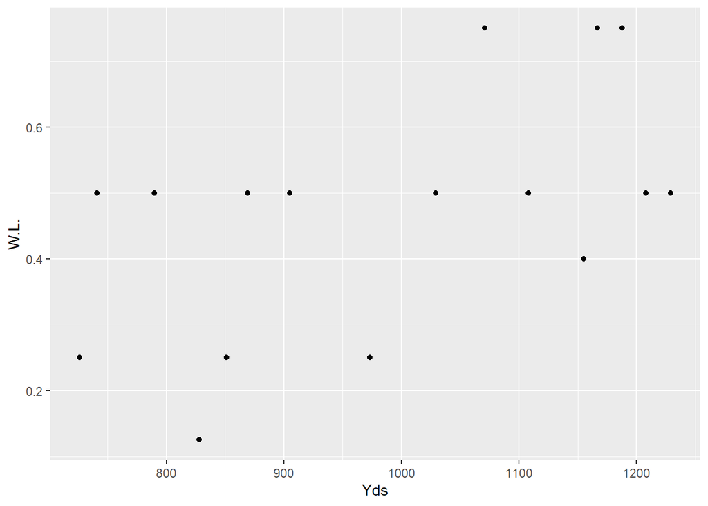

```r
ggplot(afc_pass_win, aes(x=Yds, y=W.L.)) + geom_point()
```

## Conclusion

At this point in the season there does not seem to be a strong relationship between passing yards and win percentage. There are many teams with the same .500 win percentage on all ends of the passing yardage spectrum. However, there does seem to be a slight relationship; There is no team with an above .500 win percentage with less than 1000 passing yards and there are no teams with a win percentage under .400 with over 1000 passing yards.